# Bayesian Foundations

Miles Ott

**Getting started**

- We have provided an `.Rmd` file for this activity: `R/01-foundations-activity.Rmd`.
- If you prefer to use an `R` file, first make sure that you’re working within your directory with the repo files, and then run the following from the Console:  
  `knitr::purl("R/01-foundations-activity.Rmd", "R/01-foundations-activity.R")`

  This will create an R file with the activity R code. For the corresponding discussion and prompts, see the `R/01-foundations-activity.html` file in the repo.

# Background

In Alison Bechdel’s 1985 comic strip The Rule, a character states that they only see a movie if it satisfies the following three rules:

- the movie has to have at least two women in it;
- these two women talk to each other; and
- they talk about something besides a man.

A movie that satisfies these criteria is said to have passed the “Bechdel Test”.

# Building a prior model

**Question:**  
What percentage of all recent movies do you think pass the Bechdel test?

**Question:** If you were to make a model for $\pi$, the proportion of recent movies that would pass the Bechdel test, what would it look like?

- Where would it be centered (approximately)?
- Would it be symmetric or skewed?
- How sure are you about $\pi$?

**R Exercise**

Modify the parameters in the `plot_beta()` function below to tune and plot your prior distribution for $\pi$, the proportion of recent movies that pass the Bechdel test.

Note: It may take some playing around before you land on a plot that is close to your prior understanding of $\pi$. It is OK (and encouraged!) to experiment and try multiple values for the parameters! It is also OK if your prior is different from the priors of your group mates.

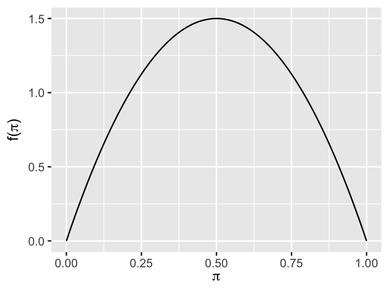

```r
# Change up the alpha and beta values (both must be positive)
library(bayesrules)
plot_beta(alpha = 2, beta = 2)
```

# Data and the Posterior

**R Exercise**

You just collected some data on 20 recent movies. It turns out that 9 of these pass the Bechdel test. Check out and discuss the corresponding *likelihood function* of $\pi$. Essentially, the higher the likelihood function at a given $\pi$ value, the more compatible our data is with that value.

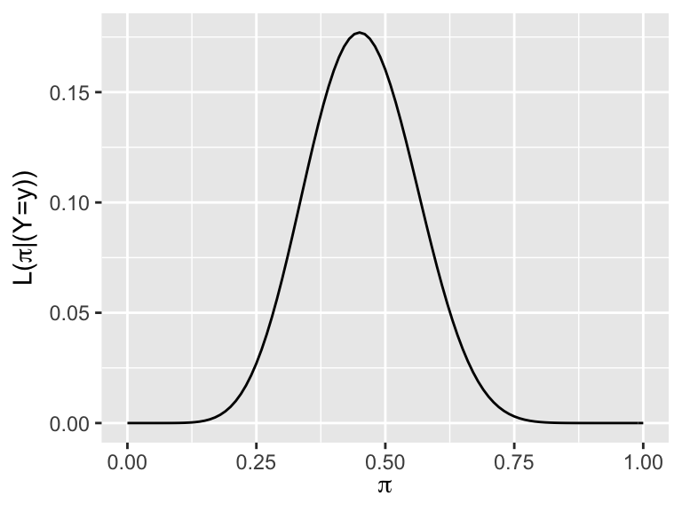

```r
plot_binomial_likelihood(y = 9, n = 20)
```

**R Exercise**

Let’s combine the prior and data to build the posterior model of $\pi$. Run the code below to learn about the parameters of the `plot_beta_binomial()` function:

```r
?plot_beta_binomial
```

Now try it out. Modify the `plot_beta_binomial()` function below to plot your prior, the likelihood, and the posterior:

```r
plot_beta_binomial(alpha = 2, beta = 2, y = 0, n = 2)
```

[output not shown]

**R Exercise**

In addition to plotting, we can also describe the prior and posterior models of $\pi$ with numeric summaries using the `summarize_beta_binomial()` function. Modify the `summarize_beta_binomial()` below to incorporate information on your prior and data that 9 out of 20 movies passed the Bechdel test. What does each number tell us?

```r
summarize_beta_binomial(alpha = 2, beta = 2, y = 0, n = 2)
```

```
##       model alpha beta      mean mode        var        sd
## 1     prior     2    2 0.5000000 0.50 0.05000000 0.2236068
## 2 posterior     2    4 0.3333333 0.25 0.03174603 0.1781742
```

# Play around

**R Exercise: Influence of the prior**

Modify the code below, keeping our data the same (9 out of 20 films passed the test), but trying out a range of different priors. How does your prior model impact the posterior?

```r
plot_beta_binomial(alpha = 2, beta = 2, y = 0, n = 2)
```

[output not shown]

```r
summarize_beta_binomial(alpha = 2, beta = 2, y = 0, n = 2)
```

```
##       model alpha beta      mean mode        var        sd
## 1     prior     2    2 0.5000000 0.50 0.05000000 0.2236068
## 2 posterior     2    4 0.3333333 0.25 0.03174603 0.1781742
```

**R Exercise: Influence of the data**

Modify the code below, starting with your original prior, but changing up the data. Instead of 9 of 20 films passing the test (45%), what if it were 27 of 60 (still 45%)? Or 45 of 100 (still 45%)? Or 450 of 1000 (still 45%)? How does the data impact the posterior?

```r
plot_beta_binomial(alpha = 2, beta = 2, y = 0, n = 2)
```

[output not shown]

```r
summarize_beta_binomial(alpha = 2, beta = 2, y = 0, n = 2)
```

```
##       model alpha beta      mean mode        var        sd
## 1     prior     2    2 0.5000000 0.50 0.05000000 0.2236068
## 2 posterior     2    4 0.3333333 0.25 0.03174603 0.1781742
```